# 4. Linear regression

Frank Edwards

## Model notation

**Likelihood**: $W \sim \textsf{Binomial}(N,p)$

**Prior**: $p \sim \textsf{Uniform}(0,1)$

- Likelihoods put probability distributions on the data
- Priors put probability distributions on the parameters (!!!)

## Building a model of human height

```r
library(rethinking)
data("Howell1")
d<-Howell1
# subset out children
d2 <- d |>
  filter(age>=18)
head(d2)
```

```
   height   weight age male
1 151.765 47.82561  63    1
2 139.700 36.48581  63    0
3 136.525 31.86484  65    0
4 156.845 53.04191  41    1
5 145.415 41.27687  51    0
6 163.830 62.99259  35    1
```

```r
nrow(d)
```

```
[1] 544
```

```r
nrow(d2)
```

```
[1] 352
```

## How to bake a Bayesian model

1. *Define the likelihood*
2. Set priors
3. Check that our priors are reasonable with simulation
4. Condition on the data
5. Visualize the posterior

## Defining our likelihood

$$h_i \sim \textsf{Normal}(\mu, \sigma)$$

## How to bake a Bayesian model

1. Define the likelihood
2. *Set priors*
3. Check that our priors are reasonable with simulation
4. Condition on the data
5. Visualize the posterior

## Simulate 4 priors for $\mu$

```r
all_the_priors <- data.frame(
  sigma1 = rnorm(1e4, 178, 1),
  sigma2 = rnorm(1e4, 178, 2),
  sigma10 = rnorm(1e4, 178, 10),
  sigma25 = rnorm(1e4, 178, 20))
```

## Distributions of priors for $\mu$

```r
all_the_priors |>
  pivot_longer(cols = everything()) |>
  ggplot(aes(x = value, color = name)) +
  geom_density() +
  labs(x = "Height in cm", color = "Mu prior")
```

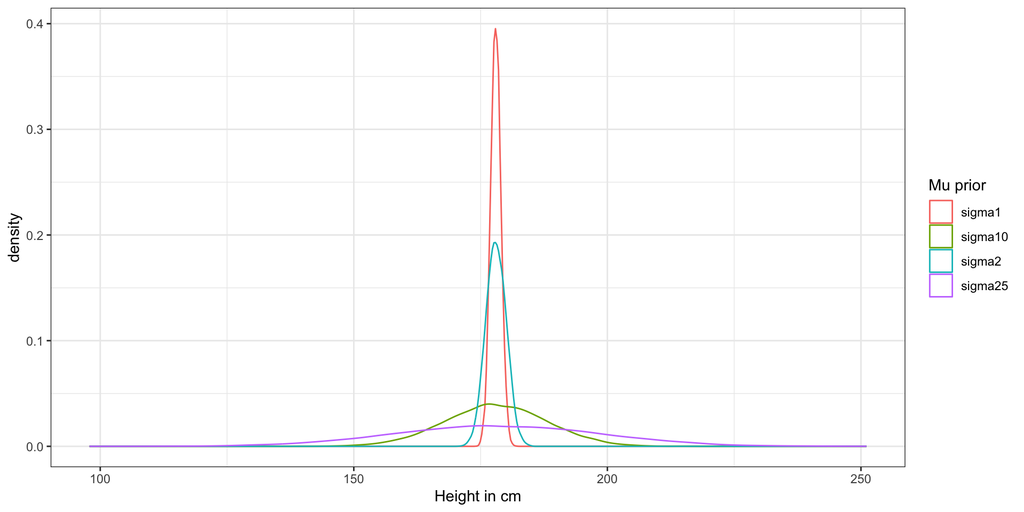

## Now for $\sigma$

- How much do individuals vary on average from the population average? How variable is height?
- Recall $sd = \sqrt{\frac{\sum{(x_i - \mu)^2}}{n}}$
- The average deviation of an observation from the mean
- $\sigma$ is constrained to be positive, our prior should reflect this

## The impact of $\sigma$ on our prior

Our prior for $\sigma$ captures our beliefs about how much variance there is within the population.

*How much variable is height across adults?*

- No idea how variable the population is: $\sigma \sim \textsf{Uniform}(0,50)$
- We know there’s not much variation: $\sigma \sim \textsf{Uniform}(0,10)$

## How to bake a Bayesian model

1. Define the likelihood
2. Set priors
3. *Check that our priors are reasonable with simulation*
4. Condition on the data
5. Visualize the posterior

## Prior simulation

1. Simulate $\mu$

```r
### simulate mu prior: mu ~ N(178, 20)
mu_sims<-rnorm(1e4, 178, 20)
```

2. Simulate $\sigma$

```r
### simulate sigma prior: sigma ~ U(0,50)
sigma_sims<-runif(1e5, 0, 50)
```

3. Draw predictions from $N(\mu, \sigma)$

```r
### prior predictive distribution: y~N(mu, sigma)
height_preds<-rnorm(1e5, mu_sims, sigma_sims)
```

## Visualize our prior

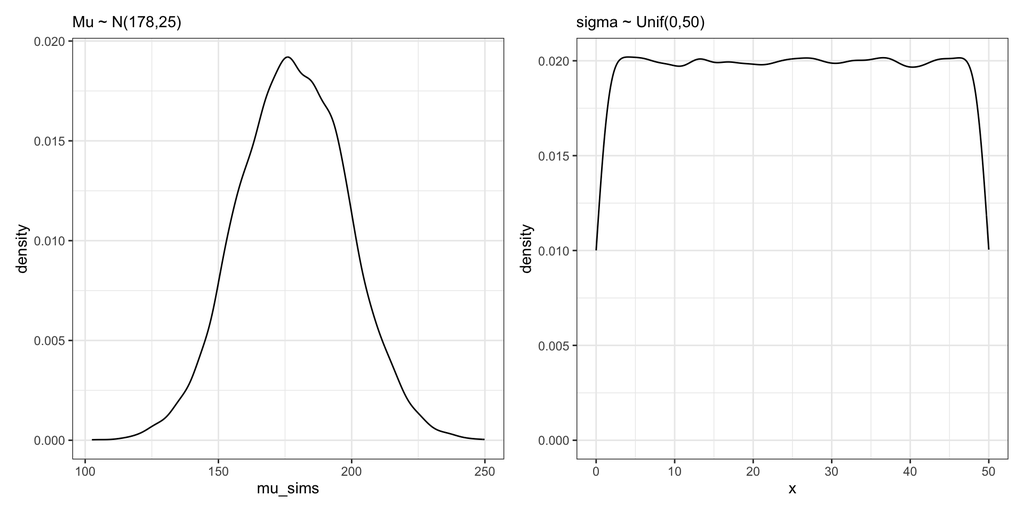

## Visualize prior predictions

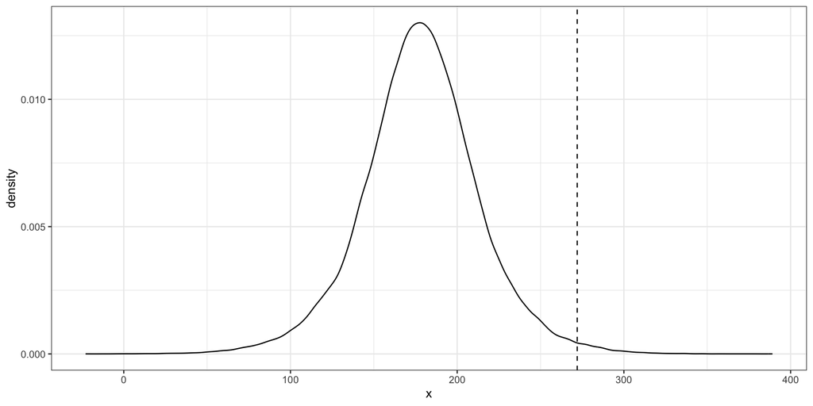

# Fitting the model

## Recipe

1. Define the likelihood
2. Set priors
3. Check that our priors are reasonable with simulation
4. *Condition on the data*
5. Visualize the posterior

## Math -> R (quap)

**Likelihood:** $h_i \sim Normal(\mu, \sigma)$

$\mu$ **Prior:** $\mu \sim Normal(178, 20)$

$\sigma$ **Prior:** $\sigma \sim Uniform(0,50)$

```r
## define model
model_formula<-alist(
  height ~ dnorm(mu, sigma),
  mu ~ dnorm(178, 20),
  sigma ~ dunif(0,50)
)
## estimate with quap
m0<-quap(model_formula, data = d2)
summary(m0)
```

```
            mean        sd       5.5%      94.5%
mu    154.607240 0.4119208 153.948911 155.265569
sigma   7.729945 0.2912553   7.264463   8.195427
```

## Math -> R (brms)

```r
prior_mu <- prior(normal(178,20), class = "Intercept")
prior_sigma <- prior(uniform(0, 50), class = "sigma", ub=50)
priors <- c(prior_mu, prior_sigma)
b0 <- brm(height ~ 1,
          family = gaussian(),
          prior = priors,
          data = d2,
          silent = 2)
```

## Model output

```r
summary(m0)
```

```
            mean        sd       5.5%      94.5%
mu    154.607240 0.4119208 153.948911 155.265569
sigma   7.729945 0.2912553   7.264463   8.195427
```

## Model output

```r
summary(b0)
```

```
 Family: gaussian
  Links: mu = identity
Formula: height ~ 1
   Data: d2 (Number of observations: 352)
  Draws: 4 chains, each with iter = 2000; warmup = 1000; thin = 1;
         total post-warmup draws = 4000

Regression Coefficients:
          Estimate Est.Error l-95% CI u-95% CI Rhat Bulk_ESS Tail_ESS
Intercept   154.61      0.41   153.80   155.43 1.00     3836     2575

Further Distributional Parameters:
      Estimate Est.Error l-95% CI u-95% CI Rhat Bulk_ESS Tail_ESS
sigma     7.77      0.30     7.21     8.39 1.00     3585     2477

Draws were sampled using sampling(NUTS). For each parameter, Bulk_ESS
and Tail_ESS are effective sample size measures, and Rhat is the potential
scale reduction factor on split chains (at convergence, Rhat = 1).
```

## Recipe

1. Define the likelihood
2. Set priors
3. Check that our priors are reasonable with simulation
4. Condition on the data
5. *Visualize the posterior*

## Sample the posterior: rethinking

```r
post_m0 <- extract.samples(m0)
head(post_m0)
```

```
        mu    sigma
1 155.0864 7.588096
2 154.6657 7.536422
3 154.5440 7.672469
4 154.2215 7.626692
5 154.0791 7.554547
6 154.7865 8.220775
```

## Sample the posterior: tidybayes + brms

```r
post_b0 <- as_draws_df(b0)
head(post_b0)
```

```
# A draws_df: 6 iterations, 1 chains, and 5 variables
  b_Intercept sigma Intercept lprior  lp__
1         155   7.5       155   -8.5 -1227
2         155   7.8       155   -8.5 -1226
3         155   8.0       155   -8.5 -1227
4         155   8.0       155   -8.5 -1227
5         155   7.9       155   -8.5 -1226
6         154   7.7       154   -8.5 -1227
# ... hidden reserved variables {'.chain', '.iteration', '.draw'}
```

## Summarizing the posterior: mu

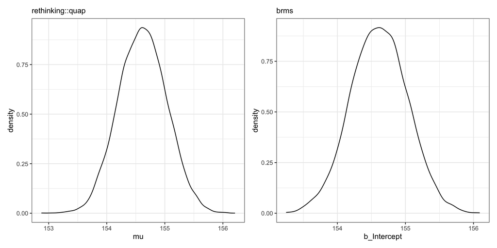

## Summarizing the posterior: sigma

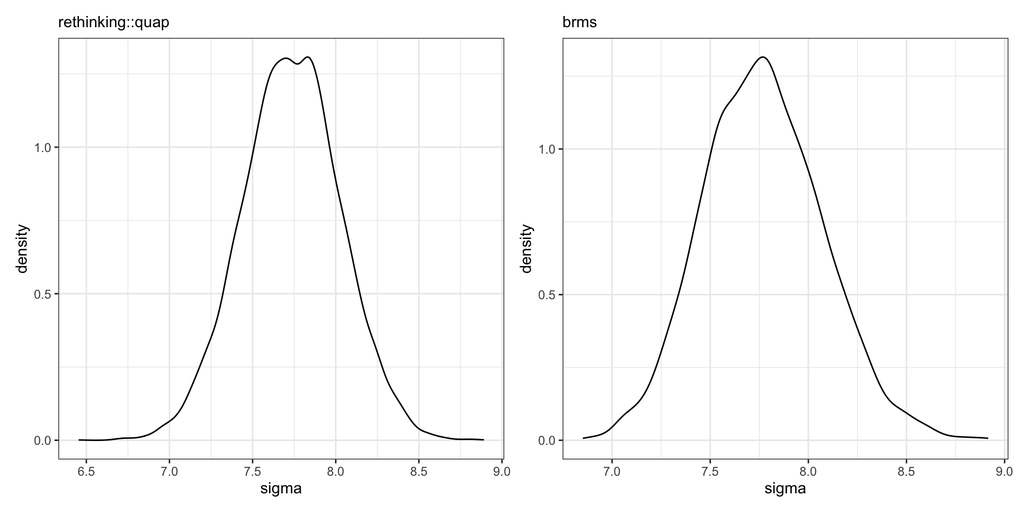

## The full posterior

```r
p1 <- ggplot(post_m0, aes(x = mu, y = sigma)) +
  geom_point(alpha = 0.1) +
  labs(subtitle = "rethinking::quap") +
  coord_cartesian(xlim=c(152, 157), ylim = c(6.5, 9))
p2 <- ggplot(post_b0, aes(x = b_Intercept, y = sigma)) +
  geom_point(alpha = 0.1) +
  labs(subtitle = "brms") +
  coord_cartesian(xlim=c(152, 157), ylim = c(6.5, 9))
p1+p2
```

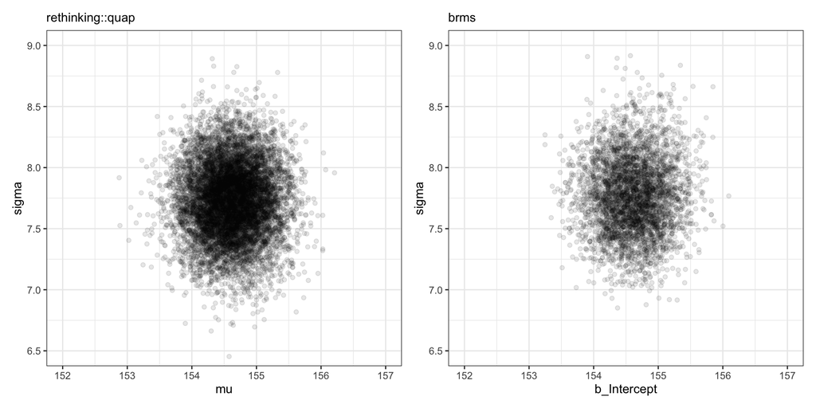

## Compare results to the prior

```r
p1<-data.frame(x = mu_sims) |>
  ggplot(aes(x = x)) +
  geom_density() +
  ggtitle("Prior, mu")+
  coord_cartesian(xlim=c(100, 250))

p2<-ggplot(post_b0,
           aes(x = b_Intercept)) +
  geom_density() +
  ggtitle("Posterior, mu") +
  coord_cartesian(xlim=c(100, 250))

p1/p2
```

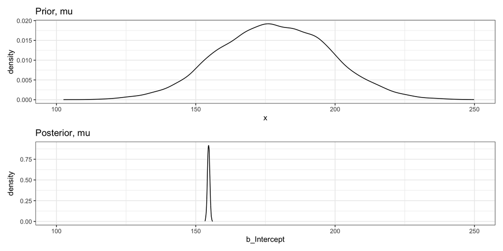

## Posterior prediction

```r
# rethinking
post_pred1 <- rnorm(1e4, post_m0$mu, post_m0$sigma)
# brms manual mode
post_pred2 <- rnorm(1e4, post_b0$b_Intercept, post_b0$sigma)
# brms easy mode, just take the first row for 'newdata' for now
post_pred3 <- predicted_draws(b0, d2[1,])
```

## Visualize posterior predictions

```r
post_pred <- ggplot(post_pred3,
       aes(x = .prediction)) +
  geom_histogram() +
  labs(subtitle = "Posterior p[redictions")
observed <- ggplot(d2,
                   aes(x = height)) +
  geom_histogram() +
  labs(subtitle = "Observed")
post_pred+observed
```

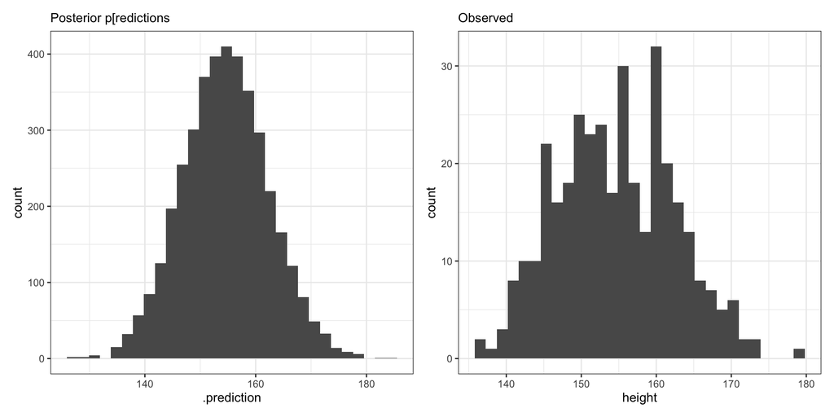

## Visualize posterior predictions (easy mode)

```r
pp_check(b0, ndraws = 50)
```

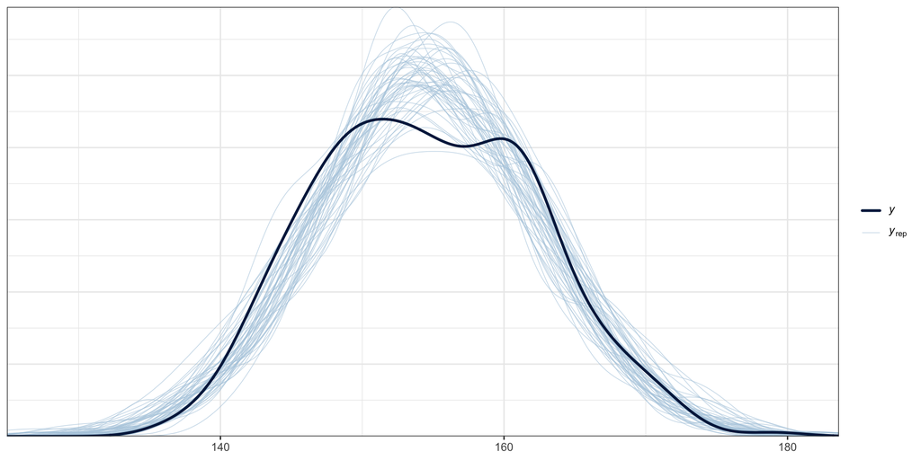

# Moving beyond an intercept-only model

## Predicting height with other variables

```r
ggplot(d2,
       aes(x = weight, y = height)) +
  geom_point()
```

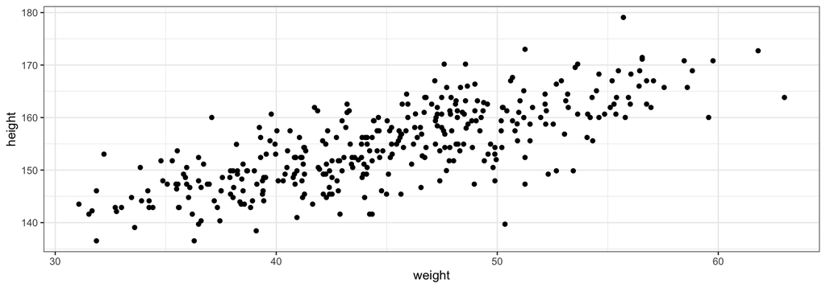

## Recipe

1. *Define the likelihood*
2. Set priors
3. Check that our priors are reasonable with simulation
4. Condition on the data
5. Visualize the posterior

## The anatomy of a linear model

Begin with the Normal model of height

$$h_i \sim \textsf{Normal}(\mu, \sigma)$$
$$\mu \sim \textsf{Normal}(178, 20)$$
$$\sigma \sim \textsf{Uniform}(0,50)$$

## Changing how we define mu

Let $x_i$ be the weight of the person in row $i$

$$h_i \sim \textsf{Normal}(\mu_i, \sigma)$$

$$\mu_i = \alpha + \beta (x_i - \bar{x})$$

## Recipe

1. Define the likelihood
2. *Set priors*
3. Check that our priors are reasonable with simulation
4. Condition on the data
5. Visualize the posterior

## Priors for our new parameters

Our prior now describes a line: $mu = \alpha + \beta x$

$$\alpha \sim \textsf{Normal}(178, 20)$$

$$\beta \sim \textsf{Normal}(0, 10)$$

## Recipe

1. Define the likelihood
2. Set priors
3. *Check that our priors are reasonable with simulation*
4. Condition on the data
5. Visualize the posterior

## What does our prior imply?

```r
## Simulate regression lines from prior and visualize
n<-100
alpha<-rnorm(n, 178, 20)
beta<-rnorm(n, 0, 10)
```

## What does our prior imply?

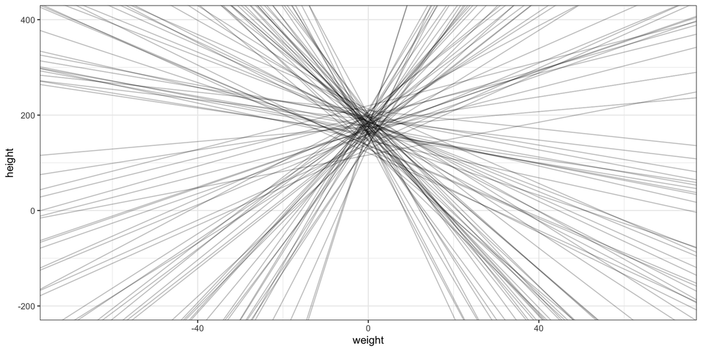

## What does our prior imply?

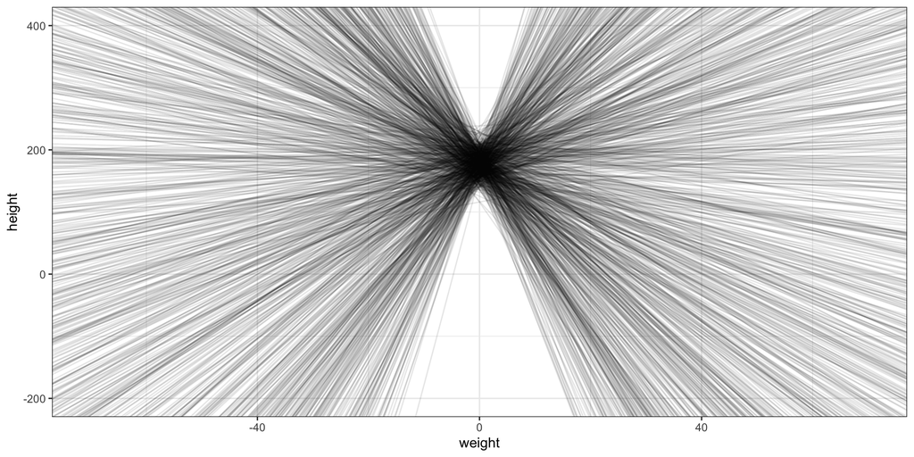

## Let’s try again

Let’s shrink the spread on $\alpha$, and set $\beta$ to be more likely positive

```r
## Simulate regression lines from prior and visualize
n<-1000
alpha<-rnorm(n, 178, 15)
beta<-rnorm(n, 2, 2)
plot_dat<-data.frame(alpha = alpha, beta=beta, sim_n = factor(1:n),
                     weight = seq(-70, 70, length.out=n),
                     height = seq(-200,400, length.out=n))
ggplot(plot_dat,
       aes(x = weight, y = height)) +
  geom_blank() +
  geom_abline(aes(intercept = alpha,
                  slope = beta,
                  group= sim_n),
              alpha = 0.1)
```

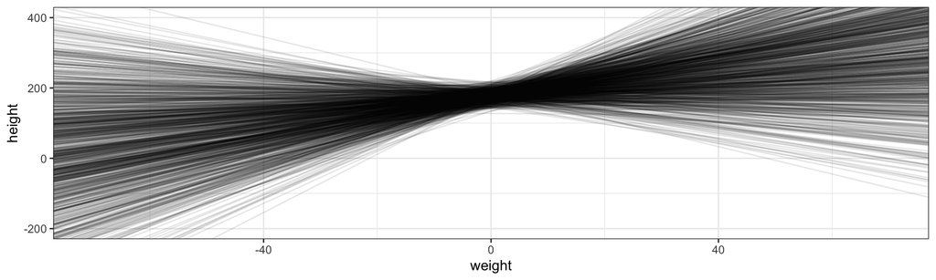

## Recipe

1. Define the likelihood
2. Set priors
3. Check that our priors are reasonable with simulation
4. *Condition on the data*
5. Visualize the posterior

## Estimating the model

- **Likelihood for height:** $h_i \sim Normal(\mu_i, \sigma)$
- **Linear model for mean:** $\mu_i = \alpha + \beta x_i$
- **Prior for intercept:** $\alpha \sim Normal(178, 15)$
- **Prior for slope:** $\beta \sim Normal(2,2)$
- **Prior for standard deviation:** $\sigma \sim Uniform(0,50)$

## Estimation

```r
# create x-xbar centered weight
d2 <- d2 |>
  mutate(weight.c = weight - mean(weight))

prior_alpha <- prior(normal(178,15), class = "Intercept")
prior_beta <- prior(normal(2, 2), class ="b")
prior_sigma <- prior(uniform(0, 50), class = "sigma", ub=50)
priors <- c(prior_alpha, prior_beta, prior_sigma)
m1 <- brm(height ~ weight.c,
          family = gaussian(),
          prior = priors,
          data = d2,
          silent = 2)
```

## Recipe

1. Define the likelihood
2. Set priors
3. Check that our priors are reasonable with simulation
4. Condition on the data
5. *Visualize the posterior*

## Interpreting the posterior: table

```r
summary(m1)
```

```
 Family: gaussian
  Links: mu = identity
Formula: height ~ weight.c
   Data: d2 (Number of observations: 352)
  Draws: 4 chains, each with iter = 2000; warmup = 1000; thin = 1;
         total post-warmup draws = 4000

Regression Coefficients:
          Estimate Est.Error l-95% CI u-95% CI Rhat Bulk_ESS Tail_ESS
Intercept   154.61      0.27   154.09   155.14 1.00     3847     3013
weight.c      0.91      0.04     0.82     0.99 1.00     4049     2979

Further Distributional Parameters:
      Estimate Est.Error l-95% CI u-95% CI Rhat Bulk_ESS Tail_ESS
sigma     5.10      0.20     4.72     5.50 1.00     4114     3078

Draws were sampled using sampling(NUTS). For each parameter, Bulk_ESS
and Tail_ESS are effective sample size measures, and Rhat is the potential
scale reduction factor on split chains (at convergence, Rhat = 1).
```

## Examining posterior samples

```r
post_m1<-as_draws_df(m1) |>
  rename(alpha = b_Intercept, beta = b_weight.c) |>
  select(alpha, beta, sigma)
head(post_m1)
```

```
# A tibble: 6 × 3
  alpha  beta sigma
  <dbl> <dbl> <dbl>
1  155. 0.874  4.78
2  154. 0.935  5.40
3  155. 0.857  4.99
4  154. 0.952  5.38
5  155. 0.900  5.21
6  155. 0.912  5.38
```

## Visualizing the estimated posterior: posterior mean

```r
plot_dat<-post_m1 |>
  summarise(a = mean(alpha), b = mean(beta))
ggplot(d2,
       aes(x = weight.c, y = height)) +
  geom_point() +
  geom_abline(data = plot_dat,
              aes(intercept = a, slope = b))
```

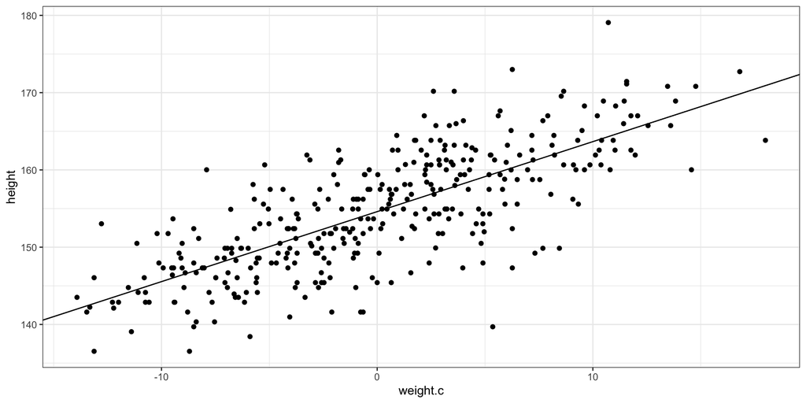

## But the posterior is more than one line

```r
ggplot(d2,
       aes(x = weight.c, y = height)) +
  geom_point() +
  geom_abline(data = post_m1[1:100,],
              aes(intercept = alpha, slope = beta), alpha = 0.1)
```

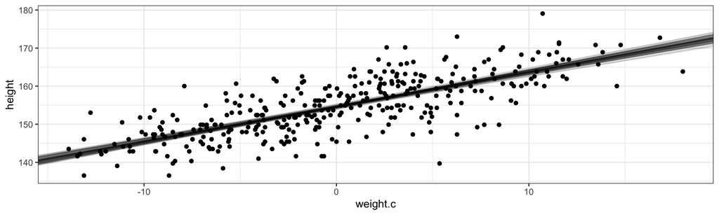

## At a single value of x

I weigh about 88 kg. Let’s solve for $h$

$$E(h_i) = \mu_i = \alpha + \beta (x_i-\bar{x})$$

```r
mu_FE<-post_m1$alpha + post_m1$beta * (88 - mean(d2$weight))
dens(mu_FE)
```

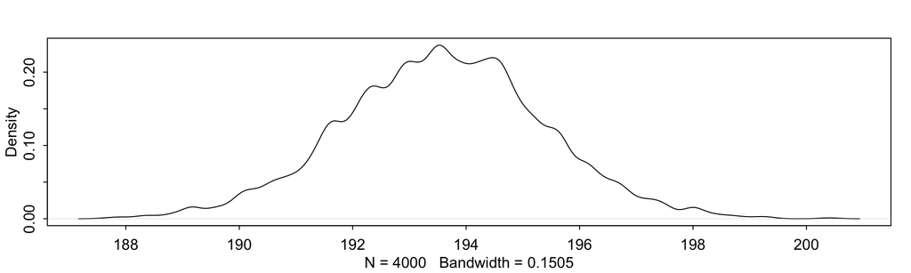

These are the values of $\mu$ for individuals of weight 88kg that are compatible with the data and the model

## A problem: extrapolation!

```r
ggplot(d2,
       aes(x = weight, y = height)) +
  geom_point()
```

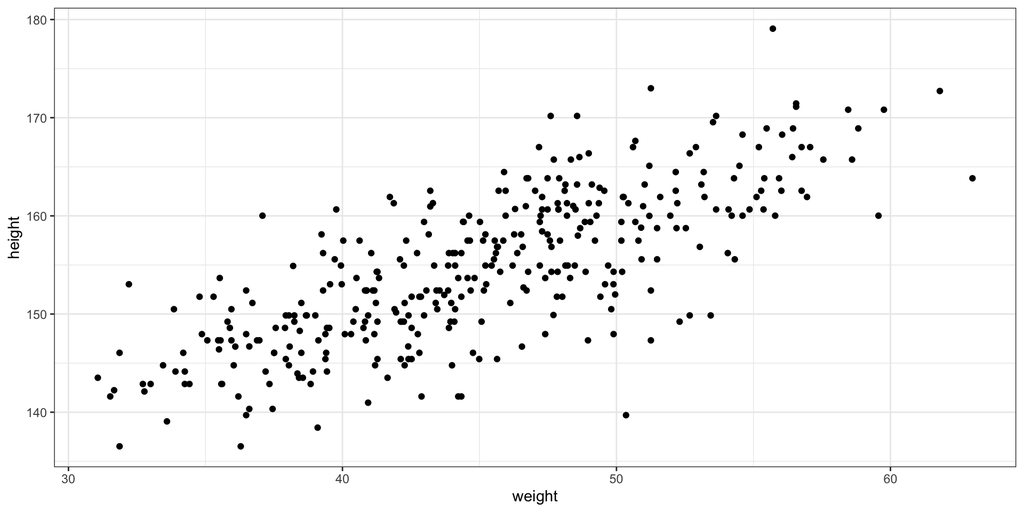

## Summarizing the posterior over the full range of the data

```r
## create a vector for the sequence of values to predict
weights<-seq(min(d2$weight), max(d2$weight), by=1)
sim_dat<-data.frame(weight.c = weights - mean(d2$weight))
## add_epred_draws adds posterior samples of the linear predictor for mu
mu<-sim_dat |>
  add_epred_draws(m1)
head(mu)
```

```
# A tibble: 6 × 6
# Groups:   weight.c, .row [1]
  weight.c  .row .chain .iteration .draw .epred
     <dbl> <int>  <int>      <int> <int>  <dbl>
1    -13.9     1     NA         NA     1   143.
2    -13.9     1     NA         NA     2   141.
3    -13.9     1     NA         NA     3   143.
4    -13.9     1     NA         NA     4   141.
5    -13.9     1     NA         NA     5   142.
6    -13.9     1     NA         NA     6   142.
```

## Visualizing the posterior for mu: with CI

```r
ggplot(mu,
       aes(x = weight.c, y = .epred)) +
  stat_lineribbon() +
  scale_fill_brewer(palette = "Blues") +
  geom_point(data = d2, aes(x = weight.c, y = height), alpha = 0.25)
```

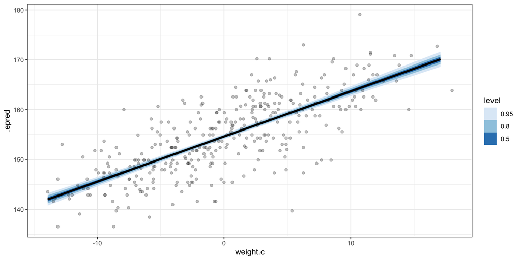

## Predicting new data; validating the model

Recall the method for posterior prediction:

1. Draw samples of the parameters from the posterior
2. Use these samples to draw new predictions using the likelihood

```r
## already got the samples in post_m1
head(post_m1)
```

```
# A tibble: 6 × 3
  alpha  beta sigma
  <dbl> <dbl> <dbl>
1  155. 0.874  4.78
2  154. 0.935  5.40
3  155. 0.857  4.99
4  154. 0.952  5.38
5  155. 0.900  5.21
6  155. 0.912  5.38
```

We haven’t used $\sigma$ yet. It will tell our model how much sampling uncertainty to produce

## Method for posterior prediction (manual)

```r
# iterate over all posterior uncertainty
n_sims <- nrow(post_m1)
# empty bucket for output
post_pred <- list()
for(i in 1:nrow(sim_dat)){
  # set up deterministic component
  linear_predictor <- post_m1$alpha + post_m1$beta * sim_dat$weight.c[i]
  # and stochastic component, draw n_sims for each weight.c and posterior combination
  post_pred[[i]] <- data.frame(ppd = rnorm(n_sims, mean = linear_predictor, sd = post_m1$sigma),
                               weight.c = sim_dat$weight.c[i])
}
post_pred <- bind_rows(post_pred)
head(post_pred)
```

```
       ppd  weight.c
1 144.6760 -13.91943
2 133.5283 -13.91943
3 144.9353 -13.91943
4 139.2127 -13.91943
5 144.8912 -13.91943
6 139.7916 -13.91943
```

## Method for posterior prediction (easy mode)

```r
sim_postpred <- sim_dat |>
  add_predicted_draws(m1)
head(sim_postpred)
```

```
# A tibble: 6 × 6
# Groups:   weight.c, .row [1]
  weight.c  .row .chain .iteration .draw .prediction
     <dbl> <int>  <int>      <int> <int>       <dbl>
1    -13.9     1     NA         NA     1        149.
2    -13.9     1     NA         NA     2        140.
3    -13.9     1     NA         NA     3        145.
4    -13.9     1     NA         NA     4        140.
5    -13.9     1     NA         NA     5        137.
6    -13.9     1     NA         NA     6        142.
```

## Visualize both sigma uncertainty

```r
ggplot(d2,
       aes(x = weight.c, y = height)) +
  geom_point() +
  # stat_lineribbon(data = mu, aes(x = weight.c, y = .epred)) +
  stat_lineribbon(data = sim_postpred, aes(x = weight.c, y = .prediction), alpha = 0.5) +
  scale_fill_brewer()
```

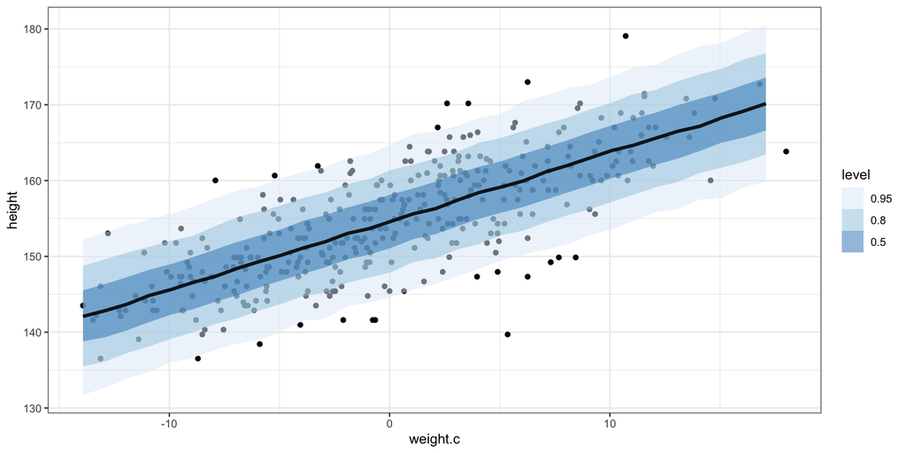

## Visualize both mu and sigma uncertainty

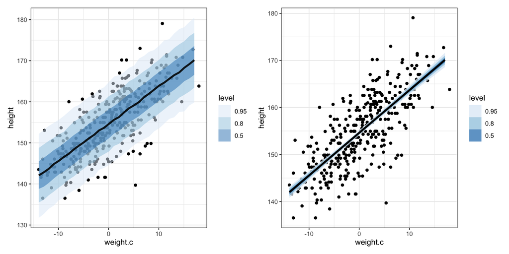